# Experiences and Perceptions of Computer Science Graduate Students

By Julie M. Smith

# Introduction

It is difficult to overstate the importance of computing in the 21st century, and as innovative technologies continue to seep into every portion of our lives, the role that computer scientists play in society expands as well. Whether it is ethical questions about the use of facial recognition to track political dissenters or technological solutions to persistent social problems, computer scientists will have an enormous impact on society. Not only that, but the field represents one of the fastest growing and best compensated. This means that the current diversity gaps in computer science (hereafter CS)– including the fact that fewer than 1 in 5 undergraduate majors is female (Bruce, 2018) – have profound repercussions. Thus, it is important to better understand the experience of CS students.

The Computing Research Association (CRA) maintains a multi-institution data set, the Data Buddies Survey. A subset of that data set was used in this study. Specifically, surveys taken by students at ten Texas colleges in 2018 were included; these students were enrolled in a graduate program in CS (n = 258; note that there were 4 respondents to the survey who were not enrolled in a CS graduate program but nonetheless completed the survey; they were removed from the data analysis.)

```r
library(tidyverse)
dbsRAW <- read_csv("DBS.csv")

#Remove respondents who are not in a CS graduate program
dbs <- dbsRAW %>%
  filter(DegreeProgramCS == 1)
```

# Description of Data

## Demographic Data

The survey gathered demographic data about disability:

```r
disabData <- dbs %>%
  group_by(DisabYN) %>%
  mutate(DisabYN = recode(DisabYN, '0' = "No", '1' = "Yes", .missing = "No answer")) %>%
  tally() %>%
  rename(Disability = DisabYN)

disabData
```

| Disability | n |
| --- | --- |
| No | 234 |
| No answer | 19 |
| Yes | 5 |

Of the 258 respondents, 5 indicated that they had a disability while 19 did not respond to the question. There is insufficient data about the number of disabled CS graduate students (Ladner, 2020) to determine whether the sample in this data set is representative of the national and/or international population of CS graduate students.

The survey also asked participants to indicate their gender:

```r
genderData <- dbs %>%
  group_by(Gender) %>%
  mutate(Gender = recode(Gender, '1' = "Woman", '2' = "Man", '3' = "Non-binary", .missing = "No answer")) %>%
  tally()

genderData
```

| Gender | n |
| --- | --- |
| Man | 159 |
| No answer | 19 |
| Non-binary | 1 |
| Woman | 79 |

There were 79 women, 159 men, and 1 non-binary person; 19 respondents didn’t answer the question.

We can summarize the demographic data as follows:

```r
library(vcd)
```

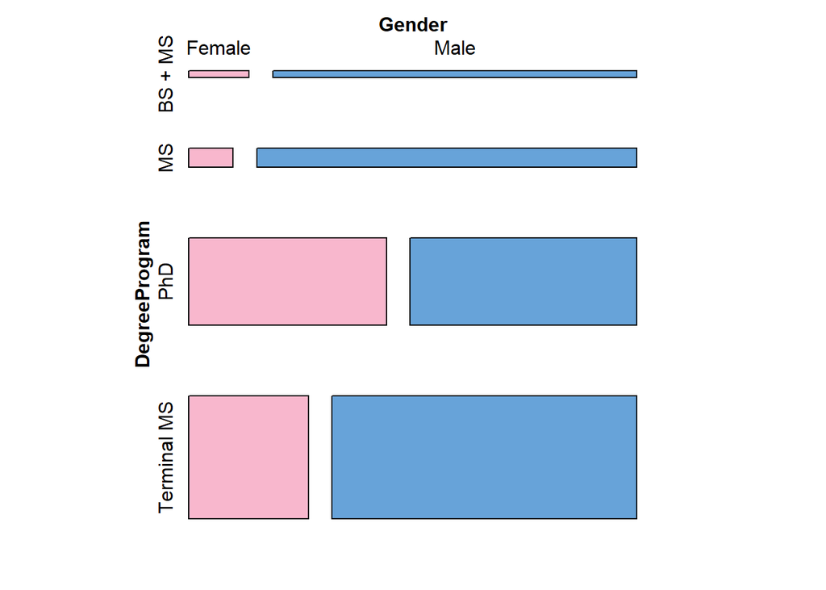

```r
demoOverview <- dbs %>%
  filter(Gender != 3) %>%
  mutate(DegreeProgram = recode(DegreeProgram, "1" = "BS + MS", "2" = "Terminal MS", "3" = "MS", "4" = "PhD")) %>%
  mutate(Gender = recode(Gender, "1" = "Female", "2" = "Male", "3" = "Non-Binary", .missing = "No Response"))

mosaic(~ DegreeProgram + Gender,
       data = demoOverview,
       highlighting = "Gender",
       highlighting_fill = c("#F8B7CD", "#67A3D9"),
       direction = c("h", "v"),
       spacing = spacing_increase(start = unit(1, "lines"), rate = 3))
```

Note that women are better represented (although still less than half) in PhD as opposed to MS programs. However, there has been criticism of the practice of simply comparing the percentage of men and women in PhD programs as opposed to comparing the percentage *relative to* the percentage of men and women prepared to enter PhD programs (Gillen & Tanenbaum, 2014).

## Activities

The Data Buddies survey collected data about participation in computing-related activities by asking respondents about their level of participation in eighteen activities, such as outreach to K12 students and participation in hackathons. All of these responses were totaled in order to generate one activity level score for each student:

```r
ActivityLevelByStudent <-dbs %>%
  mutate(Activity_Level =
           Activities1.11 + Activities10.11 + Activities11.1 + Activities12.1 +
           Activities13.1 + Activities14.1 + Activities15.1 + Activities16.1 +
           Activities17.1 + Activities18.1 + Activities2.1 + Activities3.1 +
           Activities4.1 + Activities5.1 + Activities6.11 + Activities7.1 +
           Activities8.1 + Activities9.1) %>%
  select(RespondentID, Activity_Level)

ActivityLevelSummary <- ActivityLevelByStudent %>%
  filter(!is.na(Activity_Level)) %>%
  summarize(label = "Activity Level",
            "Mean" = round(mean(Activity_Level), digits = 1),
            "Median" = round(median(Activity_Level), digits = 1),
            "Standard Deviation" = round(sd(Activity_Level), digits = 1))

ActivityLevelSummary
```

| label | Mean | Median | Standard Deviation |
| --- | --- | --- | --- |
| Activity Level | 38.6 | 36 | 11.5 |

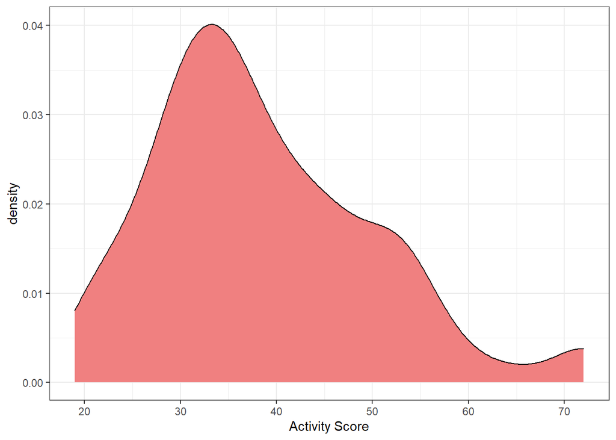

```r
ALSPlot <- ggplot(ActivityLevelByStudent, aes(x = Activity_Level)) +
  geom_density(fill = "#F08080") +
  xlab("Activity Score")  +
  theme_bw()

ALSPlot
```

The activity level score for this sample had a mean of 38.6, a median of 36, and a standard deviation of 11.5.

## Sense of Belonging

The survey asked three questions (each using a five-point Likert-type scale) to assess students’ sense of belonging in the field of CS. These scores were summed in order to generate one belonging score for each student:

```r
# Belong2.1 was re-coded because it was phrased negatively.
BelongingByStudent <- dbs %>%
  mutate("RCBelong2.1" = recode(Belong2.1, `1` = 5, `2` = 4, `3` = 3, `4` = 2, `5` = 1, .missing = NULL)) %>%
  mutate("Belonging" = Belong1 + Belong3.1 + RCBelong2.1) %>%
  select(RespondentID, Belonging, Gender, DegreeProgram)

BelongingSummary <- BelongingByStudent %>%
  filter(!is.na(Belonging)) %>%
  summarize(label = "Belonging",
            "Mean" = round(mean(Belonging), digits = 1),
            "Median" = round(median(Belonging), digits = 1),
            "Standard Deviation" = round(sd(Belonging), digits = 1))

BelongingSummary
```

| label | Mean | Median | Standard Deviation |
| --- | --- | --- | --- |
| Belonging | 12.2 | 12 | 2.4 |

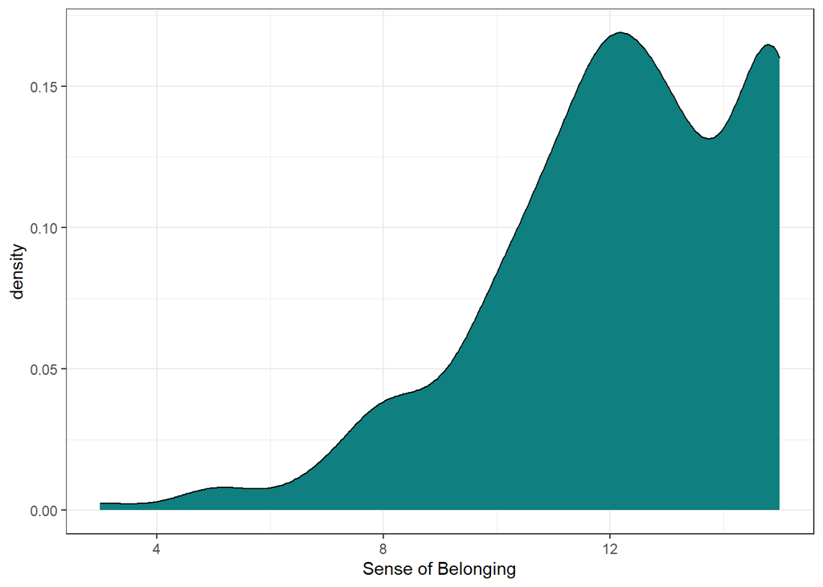

```r
BSPLot <- ggplot(BelongingByStudent, aes(x = Belonging)) +
  geom_density(fill = "#0F7F7F") +
  xlab("Sense of Belonging")  +
  theme_bw()

BSPLot
```

The overall belonging score for this sample had a mean of 12.2, a median of 12, and a standard deviation of 2.4.

## Career Interests

The Data Buddies Survey asked students to rate their interest in several different CS careers on a five-point Likert-type scale. For each student, the average (mean) of their interest in CS careers was calculated:

```r
CareerInterestbyStudent <- dbs %>%
  mutate(
    "CS_Career_Interest" = round(((CareerInterest1.1 + CareerInterest1.2 + CareerInterest2.1 +
                                     CareerInterest2.2 + CareerInterest3.1 + CareerInterest4 +
                                     CareerInterest7)/7), digits = 2)) %>%
  mutate("Non_CS_Career_Interest" = CareerInterest8) %>%
  select(RespondentID, CS_Career_Interest, Non_CS_Career_Interest, Gender)

CSCISummary <- CareerInterestbyStudent %>%
  filter(!is.na(CS_Career_Interest)) %>%
  summarize(label = "CS Career Interest",
            "Mean" = round(mean(CS_Career_Interest), digits = 1),
            "Median" = round(median(CS_Career_Interest), digits = 1),
            "Standard Deviation" = round(sd(CS_Career_Interest), digits = 1))

CSCISummary
```

| label | Mean | Median | Standard Deviation |
| --- | --- | --- | --- |
| CS Career Interest | 3.4 | 3.4 | 0.7 |

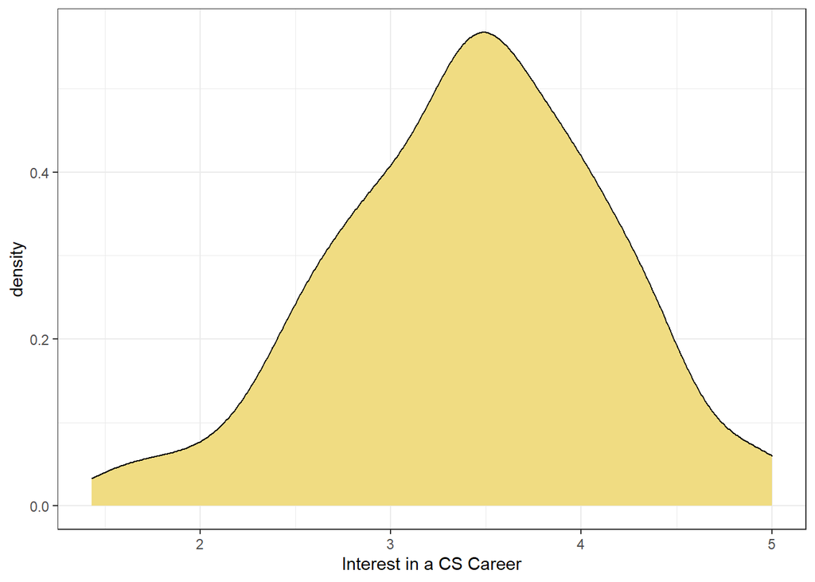

```r
CSCIPlot <- ggplot(CareerInterestbyStudent, aes(x = CS_Career_Interest)) +
  geom_density(fill = "#F0DC82") +
  xlab("Interest in a CS Career")  +
  theme_bw()

CSCIPlot
```

For the sample, the mean interest was 3.4, the median was 3.4, and the standard deviation was 0.7.

The survey also asked one question about interest in careers that were not related to CS:

```r
NonCSCISummary <- CareerInterestbyStudent %>%
  filter(!is.na(Non_CS_Career_Interest)) %>%
  summarize(label = "Non-CS Career Interest",
            "Mean" = round(mean(Non_CS_Career_Interest), digits = 1),
            "Median" = round(median(Non_CS_Career_Interest), digits = 1),
            "Standard Deviation" = round(sd(Non_CS_Career_Interest), digits = 1))

NonCSCISummary
```

| label | Mean | Median | Standard Deviation |
| --- | --- | --- | --- |
| Non-CS Career Interest | 2.2 | 2 | 1.3 |

For this data set, the sample had a mean interest of 2.2, a median of 2, and a standard deviation of 1.3. It is not surprising that students taking this survey had a higher level of interest in CS-related careers since they are in CS graduate programs.

## Self-Efficacy

The survey asked 11 questions about self-efficacy, using a five-point Likert-type scale. Student scores for all 11 questions were combined in order to generate an overall self-efficacy score:

```r
SEByStudent <-dbs %>%
  mutate(Self_Efficacy = SelfEfficacy1.1 + SelfEfficacy12 + SelfEfficacy13 + SelfEfficacy18 +
           SelfEfficacy19 + SelfEfficacy21 + SelfEfficacy22 + SelfEfficacy23 + SelfEfficacy24 +
           SelfEfficacy25 + SelfEfficacy7) %>%
  select(RespondentID, Self_Efficacy)

SESummary <- SEByStudent %>%
  filter(!is.na(Self_Efficacy)) %>%
  summarize(label = "Self-Efficacy",
            "Mean" = round(mean(Self_Efficacy), digits = 1),
            "Median" = round(median(Self_Efficacy), digits = 1),
            "Standard Deviation" = round(sd(Self_Efficacy), digits = 1)
            )
SESummary
```

| label | Mean | Median | Standard Deviation |
| --- | --- | --- | --- |
| Self-Efficacy | 45.9 | 46 | 6.7 |

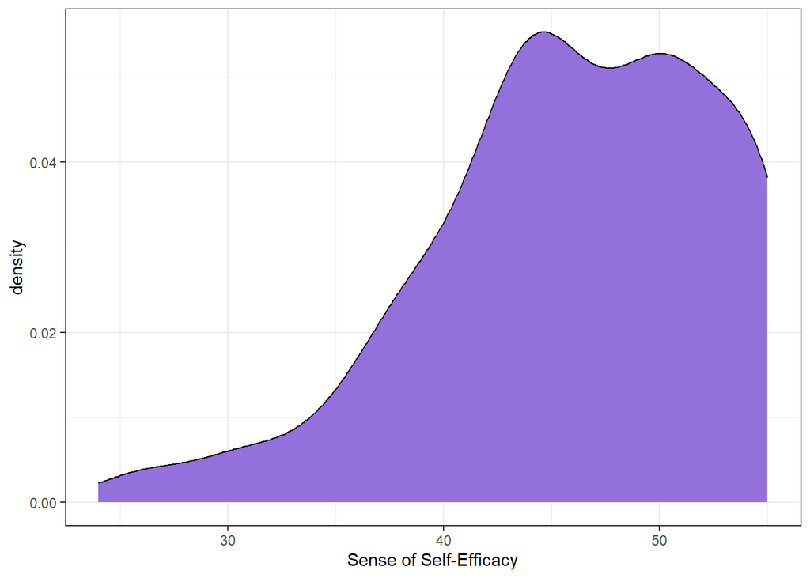

```r
SEPlot <- ggplot(SEByStudent, aes(x = Self_Efficacy)) +
  geom_density(fill = "mediumpurple") +
  xlab("Sense of Self-Efficacy") +
  theme_bw()

SEPlot
```

The mean self-efficacy score was 45.9, the median was 46, and the standard deviation was 6.7.

## Departmental Support

The final portion of the survey explored the students’ perceptions of departmental support with 7 questions, which have been summed in order to create an overall score for sense of support:

```r
# Support_dept4, Support_dept7, and Support_dept8 were recoded because they were stated negatively.
support <- dbs %>%
  mutate("Support_dept4.1" = recode(Support_dept4, `1` = 5, `2` = 4, `3` = 3, `4` = 2, `5` = 1, .missing = NULL)) %>%
  mutate("Support_dept7.1" = recode(Support_dept7, `1` = 5, `2` = 4, `3` = 3, `4` = 2, `5` = 1, .missing = NULL)) %>%
  mutate("Support_dept8.1" = recode(Support_dept8, `1` = 5, `2` = 4, `3` = 3, `4` = 2, `5` = 1, .missing = NULL)) %>%
  mutate(Dept_Support = Support_dept1 + Support_dept2 + Support_dept3 + Support_dept4.1 + Support_dept5 +
           Support_dept7.1 + Support_dept8.1) %>%
  select(RespondentID, Dept_Support)

DSsummary <- support %>%
  filter(!is.na(Dept_Support)) %>%
  summarize(label = "Perception of Support",
            "Mean" = round(mean(Dept_Support), digits = 1),
            "Median" = round(median(Dept_Support), digits = 1),
            "Standard Deviation" = round(sd(Dept_Support), digits = 1))

 DSsummary
```

| label | Mean | Median | Standard Deviation |
| --- | --- | --- | --- |
| Perception of Support | 26 | 26 | 4.6 |

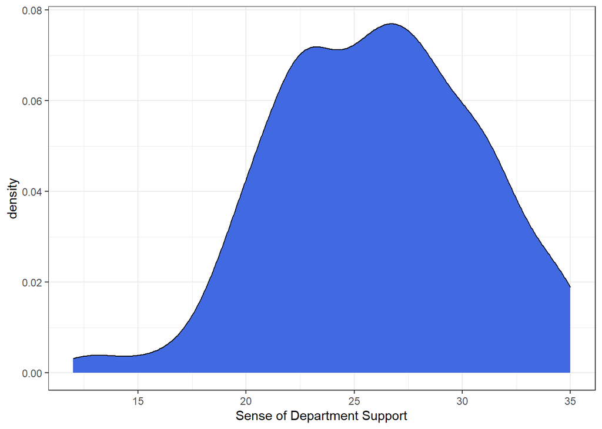

```r
 DSPlot <- ggplot(support, aes(x = Dept_Support)) +
  geom_density(fill = "royalblue") +
  xlab("Sense of Department Support")  +
  theme_bw()

DSPlot
```

The mean for sense of departmental support was 26, the median was 26, and the standard deviation was 4.6.

# Exploratory Data Analysis

There are four driving questions for the exploratory data analysis:  
RQ1: Is there a relationship between self-efficacy and activity participation rates?  
RQ2: Does sense of belonging differ by level of study and/or by gender?  
RQ3: Does career interest vary according to perceptions of departmental support, and, if so, is there a gendered dimension to this relationship?  
RQ4: Is the relationship between self-efficacy and belonging mediated by gender?

## Self-Efficacy and Activity Participation Rates

The first driving question explores whether there is a relationship between participating in CS activities and a sense of self-efficacy:

```r
RQ1 <- inner_join(SEByStudent, ActivityLevelByStudent, by = "RespondentID") %>%
  filter(!is.na(Self_Efficacy)) %>%
  filter(!is.na(Activity_Level))

round(cor(RQ1$Self_Efficacy, RQ1$Activity_Level), digits = 3)
```

```
## [1] 0.312
```

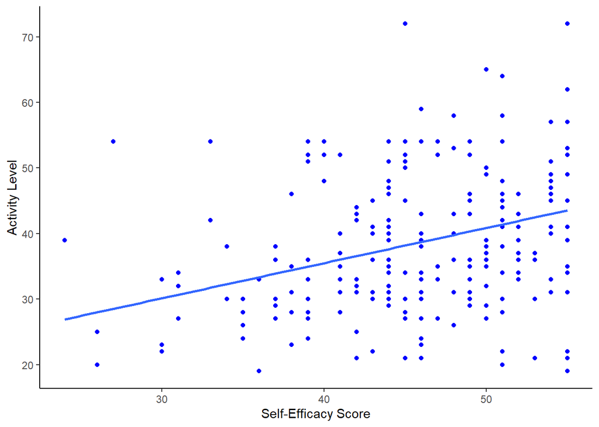

```r
ggplot(data = RQ1) +
  geom_point(mapping = aes(x = Self_Efficacy, y = Activity_Level), colour = "blue") +
  geom_smooth(method = "lm", se = FALSE, aes(x = Self_Efficacy, y = Activity_Level)) +
  xlab("Self-Efficacy Score") +
  ylab("Activity Level") +
  theme_classic()
```

With a correlation coefficient of 0.312, we can conclude that there is a positive but quite weak correlation between self-efficacy and activity levels.

## Sense of Belonging

The second research question asks: Does sense of belonging differ by level of study and/or by gender?

```r
BelongingRQ2 <- BelongingByStudent %>%
    filter(!is.na(Gender)) %>%
    filter(!is.na(Belonging)) %>%
    filter(!is.na(DegreeProgram))

round(cor(BelongingRQ2$Belonging, BelongingRQ2$Gender), digits = 3)
```

```
## [1] -0.1
```

```r
round(cor(BelongingRQ2$Belonging, BelongingRQ2$DegreeProgram), digits = 3)
```

```
## [1] -0.044
```

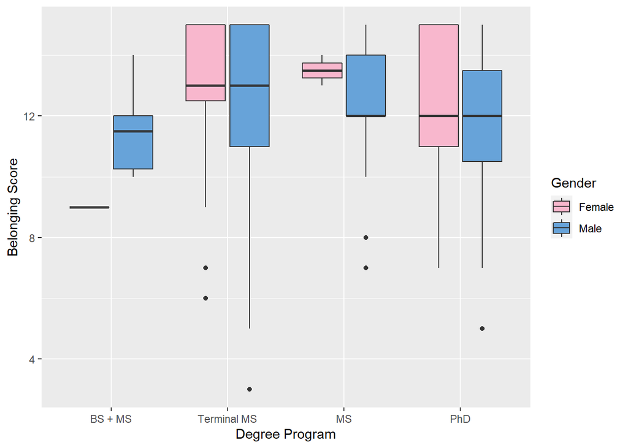

```r
BelongingRQ2.2 <- BelongingRQ2 %>%
  filter(Gender != 3) %>%
  mutate(DegreeProgram = recode(DegreeProgram, "1" = "BS + MS", "2" = "Terminal MS", "3" = "MS", "4" = "PhD")) %>%
  mutate(Gender = recode(Gender, "1" = "Female", "2" = "Male", "3" = "Non-Binary", .missing = "No Response"))

BelongingRQ2.2 %>%
  ggplot(aes(x = factor(DegreeProgram), y = Belonging, fill=factor(Gender))) + geom_boxplot() +
  xlab("Degree Program") +
  ylab("Belonging Score") +
  scale_x_discrete(limits = c("BS + MS", "Terminal MS", "MS", "PhD")) +
  labs(fill = "Gender") +
  scale_fill_manual(values = c("#F8B7CD", "#67A3D9"))
```

Note that there was virtually no correlation between sense of belonging and gender, with -0.1 correlation between the two.  
Similarly, the correlation between sense of belonging and degree program was only -.044.

Note that the one non-binary student was not included in the above data visualization since the sample size was insufficient.

## Career Interest and Sense of Support

The third driving question is: Does career interest vary according to perceptions of departmental support, and, if so, is there a gendered dimension to this relationship?

```r
CI <- inner_join(CareerInterestbyStudent, support, by = "RespondentID")  %>%
  filter(!is.na(CS_Career_Interest)) %>%
  filter(!is.na(Dept_Support))

#Correlation of Career Interest and Sense of Support
round(cor(CI$CS_Career_Interest, CI$Dept_Support), digits = 3)
```

```
## [1] -0.014
```

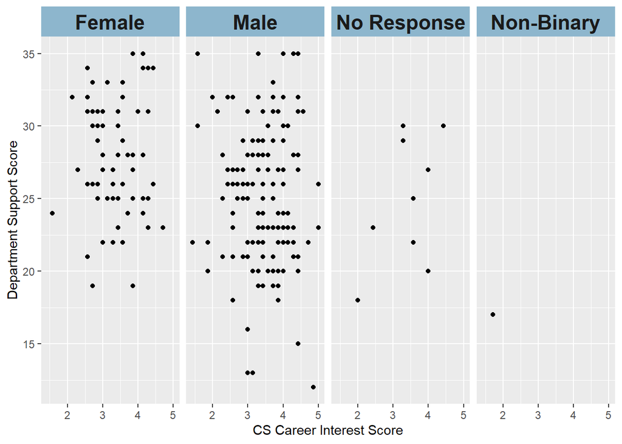

```r
CI2 <- CI %>%
  mutate(Gender = recode(Gender, "1" = "Female", "2" = "Male", "3" = "Non-Binary", .missing = "No Response"))

CIplot <- ggplot(CI2, aes(x = CS_Career_Interest, y = Dept_Support)) + geom_point() +
  xlab("CS Career Interest Score") +
  ylab("Department Support Score") +
  theme_grey()

CIplot + facet_grid(. ~Gender) +
  theme(strip.text = element_text(face = "bold", size = rel(1.5)),
        strip.background = element_rect(fill = "lightskyblue3"))
```

```r
dbsGender <- dbs %>%
  filter(Gender != 3) %>%
  select(RespondentID, Gender)

RQ3M <- CI %>%
  filter(Gender == 2)

RQ3F <- CI %>%
  filter(Gender == 1)

#Correlation of Career Interest and Sense of Support for Men
round(cor(RQ3M$CS_Career_Interest, RQ3M$Dept_Support), digit = 2)
```

```
## [1] -0.07
```

```r
#Correlation of Career Interest and Sense of Support for Women
round(cor(RQ3F$CS_Career_Interest, RQ3F$Dept_Support), digit = 2)
```

```
## [1] 0.05
```

In this sample, the correlation between career interest and sense of support was -.014, so there is virtually no correlation. For men, the correlation was -0.07 and, for women, it was 0.05, so there is no significant difference by gender, either. (Note that while one non-binary student is obviously not a large enough sample from which to draw conclusions; this data point was included to draw attention to the fact that this student is in outlier in terms of career interest and support; more research is needed on how to aid non-binary students in CS.)

## Self-Efficacy and Belonging

The final driving question is: Is the relationship between self-efficacy and belonging mediated by gender?

```r
RQ4 <- merge(BelongingByStudent, SEByStudent, by = "RespondentID") %>%
  filter((Gender == 2) | (Gender == 1))

RQ4.1M <- RQ4 %>%
  filter(Gender == 2) %>%
  filter(!is.na(Belonging)) %>%
  filter(!is.na(Self_Efficacy))

RQ4.1F <- RQ4 %>%
  filter(Gender == 1) %>%
  filter(!is.na(Belonging)) %>%
  filter(!is.na(Self_Efficacy))

#Correlation of Belonging and Self-Efficacy for Men
round(cor(RQ4.1M$Belonging, RQ4.1M$Self_Efficacy), digit = 3)
```

```
## [1] 0.498
```

```r
#Correlation of Belonging and Self-Efficacy for Women
round(cor(RQ4.1F$Belonging, RQ4.1F$Self_Efficacy), digit = 3)
```

```
## [1] 0.59
```

[output not shown]

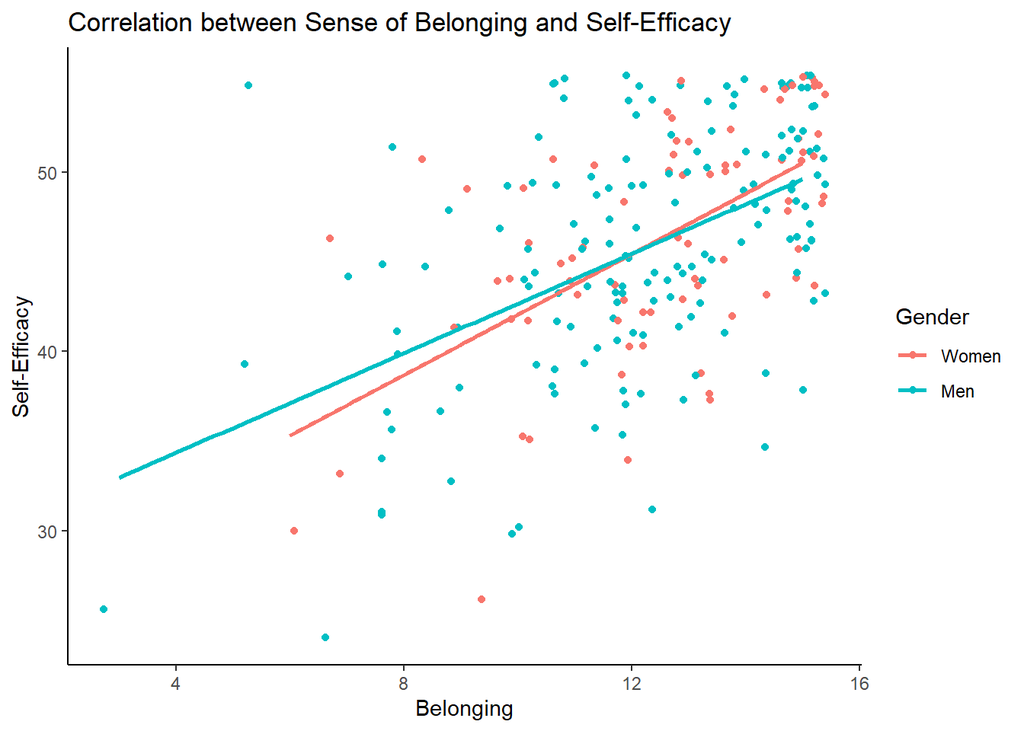

```r
ggplot(RQ4, aes(Belonging, Self_Efficacy, colour = factor(Gender))) +
    geom_point(position = "jitter") +
    stat_smooth(method = "lm", formula = y ~ x, se = FALSE) +
    ylab("Self-Efficacy") +
    labs(title="Correlation between Sense of Belonging and Self-Efficacy", colour = "Gender") +
    scale_colour_manual(values = c("#F8B7CD", "#67A3D9")) +
    scale_color_discrete(labels = c("Women", "Men")) +
  theme_classic()
```

Both genders have a fairly high degree of correlation between belonging and self-efficacy (men: 0.498; women: 0.59), although women have a slightly stronger correlation between the two.

## Discussion and Conclusion

Interestingly, in this data set, sense of belonging was not correlated to gender; this finding contradicts other research which has identified a gender gap (Lewis et al., 2017). Other studies have indicated that the presence or absence of gender stereotypes in the computing environment can correlate with a gender divide in sense of belonging (Cheryan, Plaut, Davies, & Steele, 2009), so it may be that Texas universities are doing an adequate job of creating a welcoming environment.

The data analysis discovered a positive (if weak) correlation between self-efficacy and activity levels. An important question for future research is whether increased self-efficacy leads to increased activity, or vice versa or, perhaps, whether these two factors both contribute to a virtuous cycle. While a significant amount of research has explored the link between gender and self-efficacy in CS students (Blaney & Stout, 2017; Lin, 2016), more work is needed to establish the causal relationship between these two factors.

Along these same lines, the relatively high correlation between belonging and self-efficacy (men: 0.498; women: 0.590) suggests that establishing the causality (if any) between these two factors may make it possible to improve CS education by manipulating the circumstances that lead to a sense of belonging and/or a sense of self-efficacy.

Future work could explore other data correlations; an overview of the correlations in this data set is shown below:

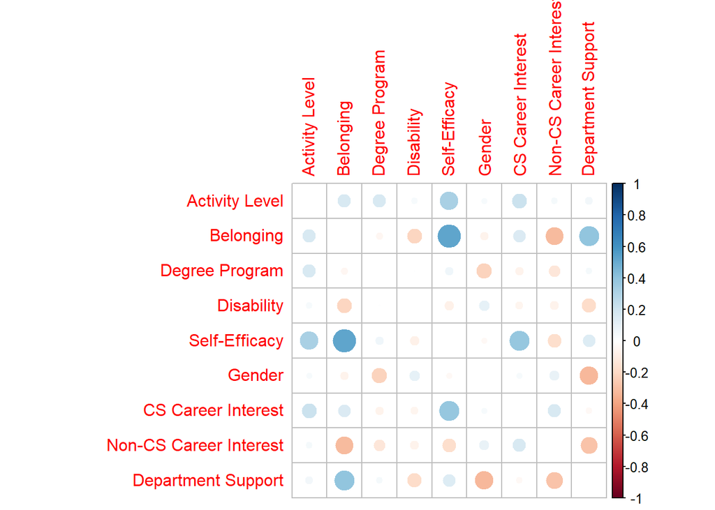

```r
  dbscor <- dbs %>%
    merge(ActivityLevelByStudent) %>%
    filter(!is.na(Activity_Level)) %>%
    merge(BelongingByStudent) %>%
    filter(!is.na(Belonging)) %>%
    merge(SEByStudent) %>%
    filter(!is.na(Self_Efficacy)) %>%
    merge(CareerInterestbyStudent) %>%
    filter(!is.na(CS_Career_Interest)) %>%
    merge(support) %>%
    filter(!is.na(Dept_Support)) %>%
    filter(!is.na(DisabYN)) %>%
    filter(!is.na(Gender)) %>%
    select(Activity_Level, Belonging, DegreeProgram, DisabYN, Self_Efficacy, Gender,CS_Career_Interest, Non_CS_Career_Interest, Dept_Support)

dbscor1 <- cor(dbscor)

colnames(dbscor1) <- c("Activity Level", "Belonging", "Degree Program", "Disability", "Self-Efficacy", "Gender", "CS Career Interest", "Non-CS Career Interest", "Department Support")

rownames(dbscor1) <- c("Activity Level", "Belonging", "Degree Program", "Disability", "Self-Efficacy", "Gender", "CS Career Interest", "Non-CS Career Interest", "Department Support")

library(corrplot)
corrplot(dbscor1, diag = FALSE)
```

Another venue for exploration would be to disaggregate the combined scores for self-efficacy, career interest, activities, belonging, and sense of department support that were created for this project since it might be the case that individual values have strong correlations to other factors that are masked when the individual values are merged into a combined score.

## Acknowledgments

The Data Buddies Survey was made possible by National Science Foundation (NSF) grants CNS-1246649, DUE-1431112, and DUE 1821136 awarded to the Computing Research Association (CRA). Any opinions, findings, and conclusions or recommendations expressed in this material are those of the author and do not necessarily reflect the views of NSF or CRA.  
Permission was sought and granted to use the Data Buddies Survey in this project.

## References

Blaney, J. M., & Stout, J. G. (2017, March). Examining the relationship between introductory computing course experiences, self-efficacy, and belonging among first-generation college women. In *Proceedings of the 2017 ACM SIGCSE Technical Symposium on Computer Science Education* (pp. 69-74).

Bruce, K. B. (2018). Five big open questions in computing education. *ACM Inroads*, 9(4), 77–80.

Cheryan, S., Plaut, V. C., Davies, P. G., & Steele, C. M. (2009). Ambient belonging: how stereotypical cues impact gender participation in computer science. *Journal of personality and social psychology*, 97(6), 1045.

Computing Research Association, Center for Evaluating the Research Pipeline. 2019. CRA Data Buddies Survey Graduate Student Dataset (2018), Washington, DC. http://www.cra.org/data-buddies

Gillen, A. and Tanenbaum, C. (2014). Exploring gender imbalance among STEM doctoral degree recipients. Retrieved from https://www.air.org/sites/default/files/downloads/report/STEM%20PhDs%20Gender%20Imbalance%20Sept%202014c.pdf

Ladner, R. (2020). Expanding the pipeline: The status of persons with disabilities in the computer science pipeline. Retrieved from https://cra.org/crn/2020/11/expanding-the-pipeline-the-status-of-persons-with-disabilities-in-the-computer-science-pipeline/

Lewis, K. L., Stout, J. G., Finkelstein, N. D., Pollock, S. J., Miyake, A., Cohen, G. L., & Ito, T. A. (2017). Fitting in to move forward: Belonging, gender, and persistence in the physical sciences, technology, engineering, and mathematics (pSTEM). *Psychology of Women Quarterly*, 41(4), 420-436.

Lin, G. Y. (2016). Self-efficacy beliefs and their sources in undergraduate computing disciplines: An examination of gender and persistence. *Journal of Educational Computing Research*, 53(4), 540-561.